# MScA, Bayesian Methods (32014) Week 5: Workshop

Yuri Balasanov, © iLykei 2016

# 1 References

[G] Andrew Gelman, John B. Carlin, Hal S. Stern, David B. Dunson, Aki Vehtari, Donald B. Rubin, Bayesian Data Analysis, Third Edition, 2013, Taylor & Francis Group.  
[K] John K. Kruschke, Doing Bayesian Data Analysis, A Tutorial with R, JAGS, and STAN, 2015, Elsevier.

# 2 Model Comparison

Define the model.

```r
modelString="
model {
  for (i in 1:Ntotal) {
    y[i]~dbern(theta)
  }
  theta~dbeta(omega[m]*(kappa-2)+1,(1-omega[m])*(kappa-2)+1)
  omega[1]<-.25
  omega[2]<-.75
  kappa<-12
  m~dcat(mPriorProb[])
  mPriorProb[1]<-.5
  mPriorProb[2]<-.5
}
"
writeLines(modelString,con="Tempmodel.txt")
```

In this model there there are 2 different prior distributions for the data parameter $\theta$.  
For $m=1$ the prior is concentrated around $\omega_1=0.25$ and for $m=2$ the prior is concentrated around $\omega_2=0.75$.  
Concentration levels are the same $\kappa=12$.  
The resulting parameters of beta distribution are: $(\alpha_1=3.5,\beta_1=8.5)$ and $(\alpha_2=8.5,\beta_2=3.5)$, correspondingly.

Create list of data corresponding to 6 successes out of 9 trials.

```r
y<-c(rep(0,3),rep(1,6))
(Ntotal<-length(y))
```

```
## [1] 9
```

```r
(dataList<-list(y=y,Ntotal=Ntotal))
```

```
## $y
## [1] 0 0 0 1 1 1 1 1 1
##
## $Ntotal
## [1] 9
```

Send model to JAGS.

```r
library(rjags)
```

```r
jagsModel<-jags.model(file="TempModel.txt",data=dataList,n.chains=4,n.adapt=500)
names(jagsModel)
```

```
## [1] "ptr"       "data"      "model"     "state"     "nchain"    "iter"
## [7] "sync"      "recompile"
```

Burn in.

```r
update(jagsModel,n.iter=600)
```

Generate MCMC trajectories.

```r
codaSamples<-coda.samples(jagsModel,variable.names=c("m"),thin=1,n.iter=5000)
list.samplers(jagsModel)
```

```
## $`bugs::ConjugateBeta`
## [1] "theta"
##
## $`base::Finite`
## [1] "m"
```

```r
head(codaSamples)
```

```
## [[1]]
## Markov Chain Monte Carlo (MCMC) output:
## Start = 601
## End = 607
## Thinning interval = 1
##      m
## [1,] 1
## [2,] 1
## [3,] 2
## [4,] 2
## [5,] 2
## [6,] 2
## [7,] 2
##
## [[2]]
## Markov Chain Monte Carlo (MCMC) output:
## Start = 601
## End = 607
## Thinning interval = 1
##      m
## [1,] 2
## [2,] 2
## [3,] 2
## [4,] 2
## [5,] 2
## [6,] 2
## [7,] 2
##
## [[3]]
## Markov Chain Monte Carlo (MCMC) output:
## Start = 601
## End = 607
## Thinning interval = 1
##      m
## [1,] 2
## [2,] 2
## [3,] 2
## [4,] 2
## [5,] 2
## [6,] 2
## [7,] 2
##
## [[4]]
## Markov Chain Monte Carlo (MCMC) output:
## Start = 601
## End = 607
## Thinning interval = 1
##      m
## [1,] 2
## [2,] 2
## [3,] 2
## [4,] 1
## [5,] 1
## [6,] 2
## [7,] 2
##
## attr(,"class")
## [1] "mcmc.list"
```

Analyze convergence.

```r
summary(codaSamples)
```

```
##
## Iterations = 601:5600
## Thinning interval = 1
## Number of chains = 4
## Sample size per chain = 5000
##
## 1. Empirical mean and standard deviation for each variable,
##    plus standard error of the mean:
##
##           Mean             SD       Naive SE Time-series SE
##       1.822450       0.382143       0.002702       0.005023
##
## 2. Quantiles for each variable:
##
##  2.5%   25%   50%   75% 97.5%
##     1     2     2     2     2
```

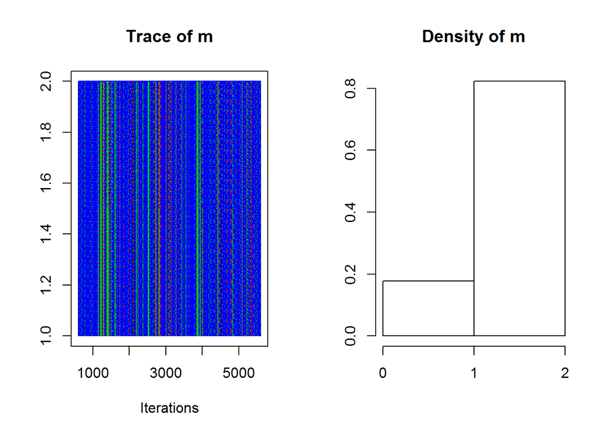

```r
plot(codaSamples)
```

Plot of the samples is not very informative because each sample is a trajectory switching between 1 and 2.

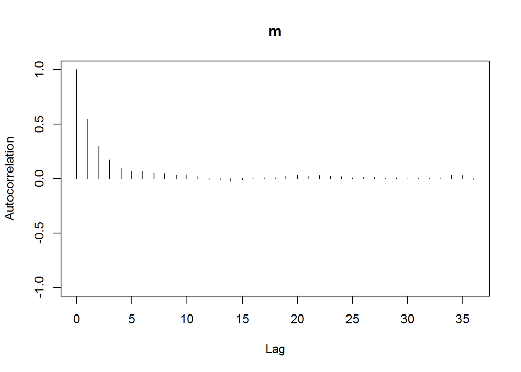

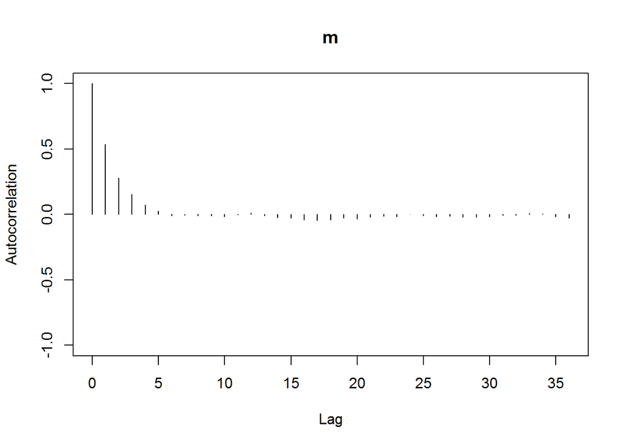

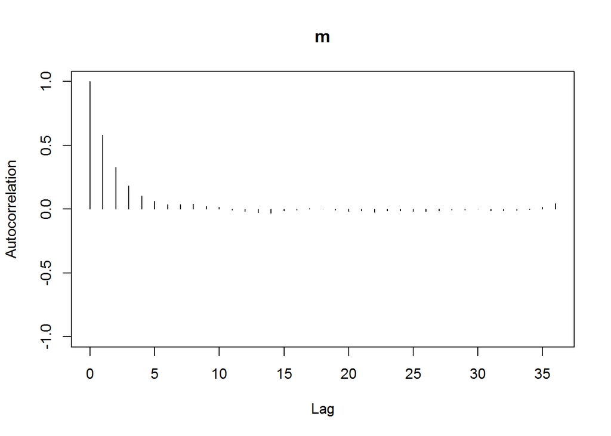

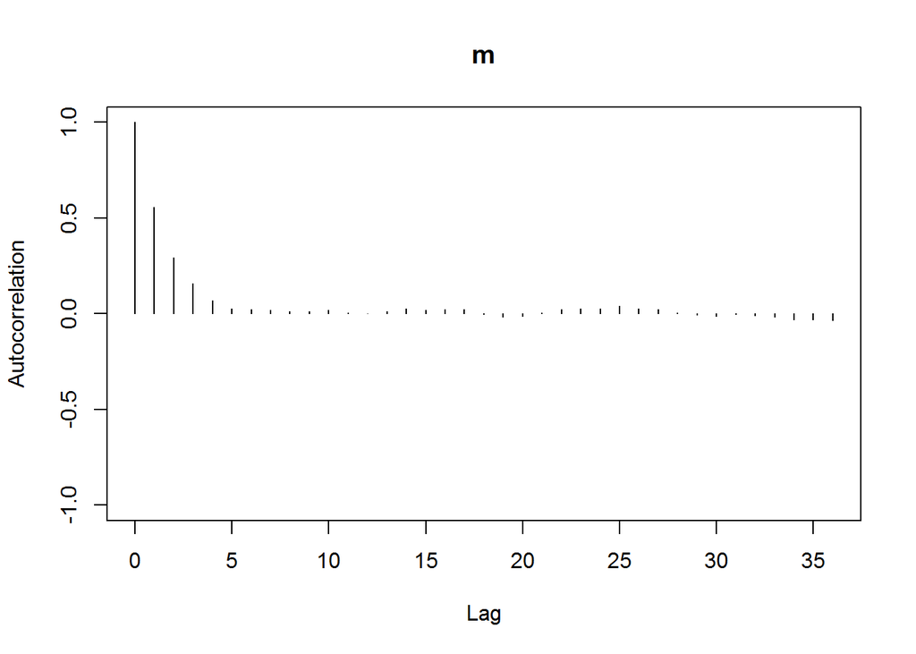

```r
autocorr.plot(codaSamples,ask=F)
```

```r
effectiveSize(codaSamples)
```

```
##       m
## 5810.61
```

We see that autocorrelation converges to zero only in about 5 lags or so.  
This is confirmed by ESS.

Rerun the chains with thinning paramater equal to 5.

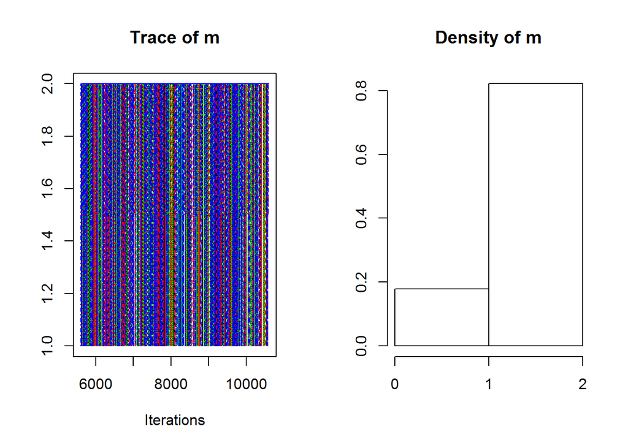

```r
codaSamples<-coda.samples(jagsModel,variable.names=c("m"),thin=5,n.iter=5000)
plot(codaSamples)
```

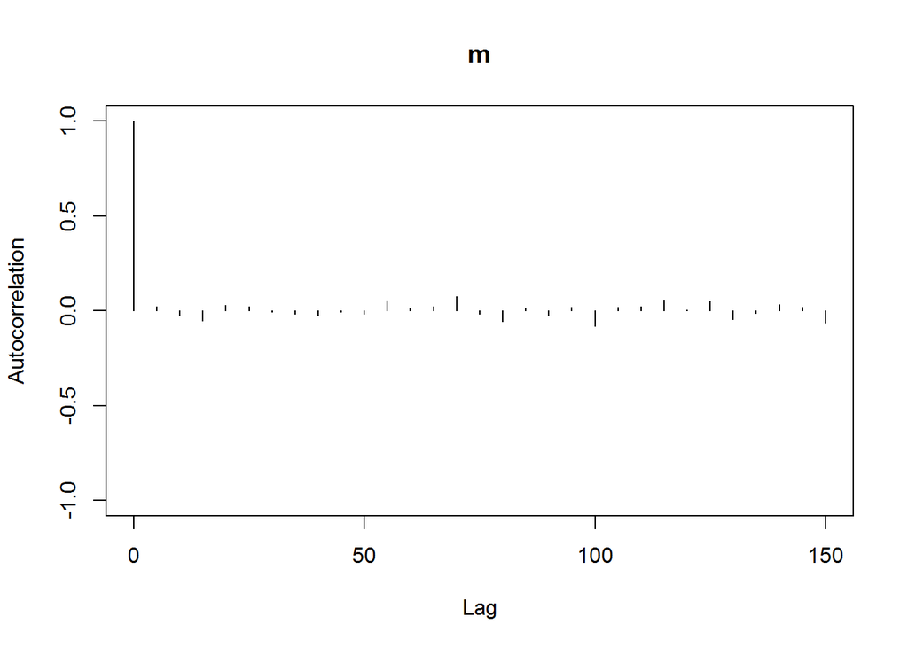

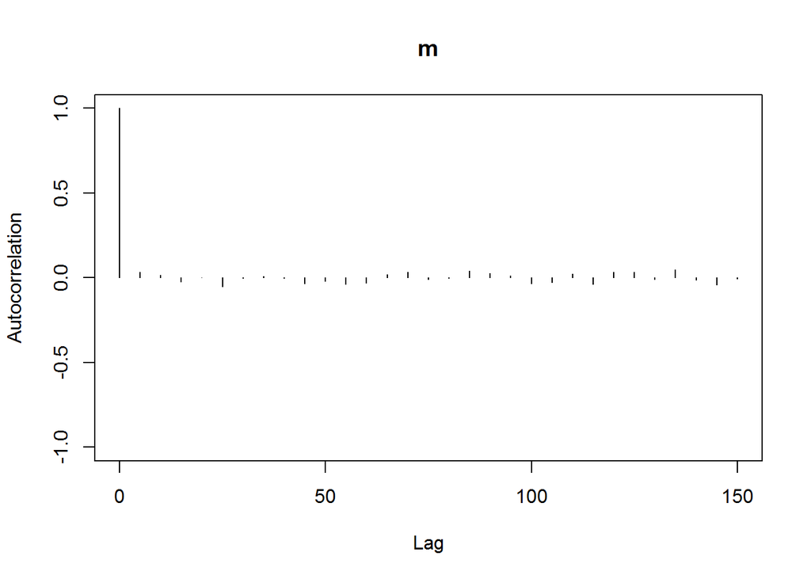

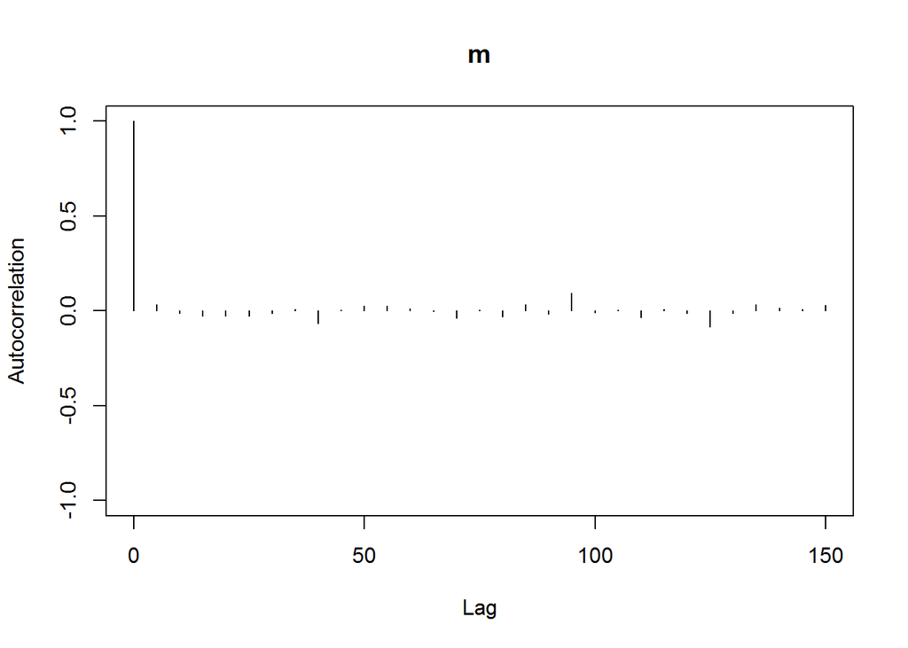

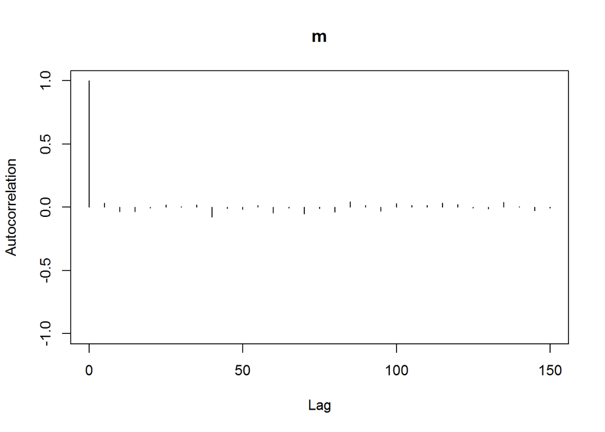

```r
autocorr.plot(codaSamples,ask=F)
```

```r
effectiveSize(codaSamples)
```

```
##    m
## 4000
```

```r
lapply(codaSamples,length)
```

```
## [[1]]
## [1] 1000
##
## [[2]]
## [1] 1000
##
## [[3]]
## [1] 1000
##
## [[4]]
## [1] 1000
```

Now autocorrelation function is not significant.  
Effective size is 4000, but this is out of total 4,000 of observations instead of 20,000. **Thinning reduces sample. When we apply thinning we need to make sample longer.**

Potential scale reduction factor or shrink factor showed convergence.

```r
gelman.diag(codaSamples)
```

```
## Potential scale reduction factors:
##
##   Point est. Upper C.I.
## m          1       1.01
```

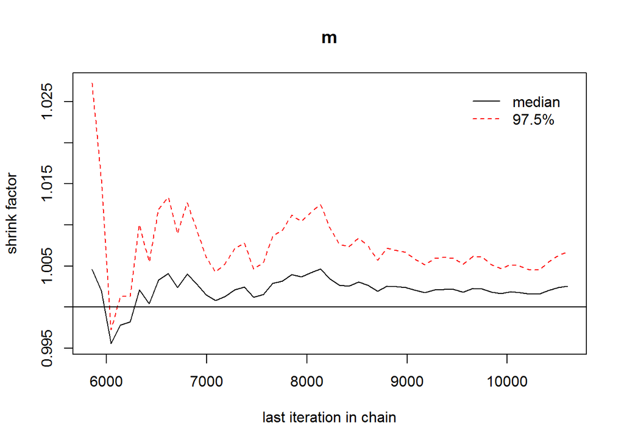

```r
gelman.plot(codaSamples)
```

Now analyze the results.

Look at the chain means.

```r
(means<-lapply(codaSamples,mean))
```

```
## [[1]]
## [1] 1.811
##
## [[2]]
## [1] 1.796
##
## [[3]]
## [1] 1.834
##
## [[4]]
## [1] 1.843
```

Find posterior probabilities of $m=2$ for each of the 4 chains and their average.

```r
(prob.2<-lapply(means,function(z) z-1))
```

```
## [[1]]
## [1] 0.811
##
## [[2]]
## [1] 0.796
##
## [[3]]
## [1] 0.834
##
## [[4]]
## [1] 0.843
```

```r
mean(unlist(prob.2))
```

```
## [1] 0.821
```

This means that posterior probability of $m=1$ is 0.179.  
Obviously, observing 6 successes out of 9 is more consistent with the model concentrating around level of 0.75.

Find how much time each chain spent in each of the state for $m$.

```r
lapply(codaSamples,function(z) sum(z==2)/length(z))
```

```
## [[1]]
## [1] 0.811
##
## [[2]]
## [1] 0.796
##
## [[3]]
## [1] 0.834
##
## [[4]]
## [1] 0.843
```

This is a caveat of using hierarchical model for model comparison: if one of the models is a strong leader the sample for the underdog becomes too short which leads to more unstable results.  
One obvious way to overcome this is to sacrifice efficiency and run chains longer.  
Also, it may be a good idea to try avoiding significant difference in prior probabilities of competing models.

# 3 Application of Stan

```r
source(paste(datapath,"DBDA2E-utilities.R",sep="/"))
```

```
##
## Kruschke, J. K. (2015). Doing Bayesian Data Analysis, Second Edition:
## A Tutorial with R, JAGS, and Stan. Academic Press / Elsevier.
```

```r
library(rstan)
#
HDIofMCMC
```

```
## function (sampleVec, credMass = 0.95)
## {
##     sortedPts = sort(sampleVec)
##     ciIdxInc = ceiling(credMass * length(sortedPts))
##     nCIs = length(sortedPts) - ciIdxInc
##     ciWidth = rep(0, nCIs)
##     for (i in 1:nCIs) {
##         ciWidth[i] = sortedPts[i + ciIdxInc] - sortedPts[i]
##     }
##     HDImin = sortedPts[which.min(ciWidth)]
##     HDImax = sortedPts[which.min(ciWidth) + ciIdxInc]
##     HDIlim = c(HDImin, HDImax)
##     return(HDIlim)
## }
```

## 3.1 Estimation of binomial probability

Consider a simple problem of estimation of parameter of binomial distribution.

Specification of model is similar to JAGS.

```r
# Specify model:
modelString = "
  data {
    int<lower=0> N ;
    int y[N] ; //length-N vector of integers
  }
  parameters {
    real<lower=0,upper=1> theta ;
  }
  model {
    theta ~ beta(1,1) ;
    y ~ bernoulli(theta) ;
  }
" # close quote for modelString
```

Stan is based on C++ library. That is why the model description must be translated into C++. Then it compiles and becomes an executable dynamic shared object (DSO).  
This is done by `stan_model()`.

```r
# Translate model to C++ and compile to DSO:
stanDso <- stan_model( model_code=modelString )
```

[output not shown]

Data are specified similar to JAGS.

```r
# Specify data:
N = 50 ; z = 10
y = c(rep(1,z),rep(0,N-z))
dataList = list(
  y = y ,
  N = N
)
```

Running MCMC is done by `sampling()`.
Argument `warmup` has the same meaning as “burn in”.
Argument ’iter` is total number of steps per chain, including warmup period.
The total number of steps used for sampling from posterior distribution is
$$\frac{chains \times (iter~-~warmup)}{thin}$$
.

Argument `init` is not used in the following call allowing Stan to used default random initiation.

```r
# Generate posterior sample:
stanFit <- sampling( object=stanDso ,
                     data = dataList ,
                     chains = 3 ,
                     iter = 1000 ,
                     warmup = 200 ,
                     thin = 1 )
```

[output not shown]

[output cut: 16 more lines]

```
## Iteration: 100 / 1000 [ 10%]  (Warmup)
## Iteration: 200 / 1000 [ 20%]  (Warmup)
## Iteration: 201 / 1000 [ 20%]  (Sampling)
## Iteration: 300 / 1000 [ 30%]  (Sampling)
## Iteration: 400 / 1000 [ 40%]  (Sampling)
## Iteration: 500 / 1000 [ 50%]  (Sampling)
## Iteration: 600 / 1000 [ 60%]  (Sampling)
## Iteration: 700 / 1000 [ 70%]  (Sampling)
## Iteration: 800 / 1000 [ 80%]  (Sampling)
## Iteration: 900 / 1000 [ 90%]  (Sampling)
## Iteration: 1000 / 1000 [100%]  (Sampling)
##
##  Elapsed Time: 0.002 seconds (Warm-up)
##                0.01 seconds (Sampling)
##                0.012 seconds (Total)
```

```r
class(stanFit)
```

```
## [1] "stanfit"
## attr(,"package")
## [1] "rstan"
```

Use application `shinystan` for exploration of the MCMC object.

```r
library(shinystan)
```

Run application `launch_shinystan()`

```r
#Not evaluated in Rmd
launch_shinystan(stanFit)
```

Or create an object of shinystan application and save it to load and run it later.

```r
myFirstStanFit<-as.shinystan(stanFit)
save(myFirstStanFit,file=paste(datapath,"firststanfit.Rdata",sep="/"))
```

```r
load(paste(datapath,"firststanfit.Rdata",sep="/"))
launch_shinystan(myFirstStanFit)
```

Use standard graphs from Stan or from [K].

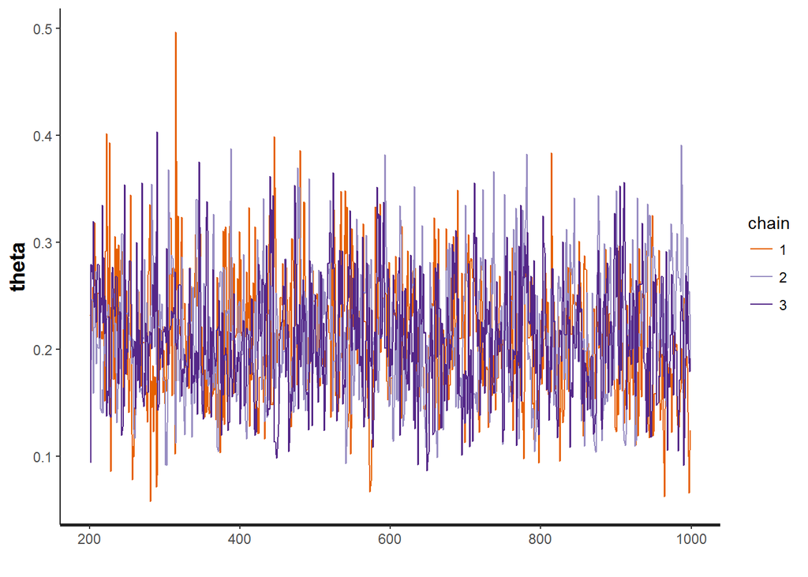

```r
#openGraph()
traceplot(stanFit,pars=c("theta"))
```

```
## ci_level: 0.8 (80% intervals)
```

```
## outer_level: 0.95 (95% intervals)
```

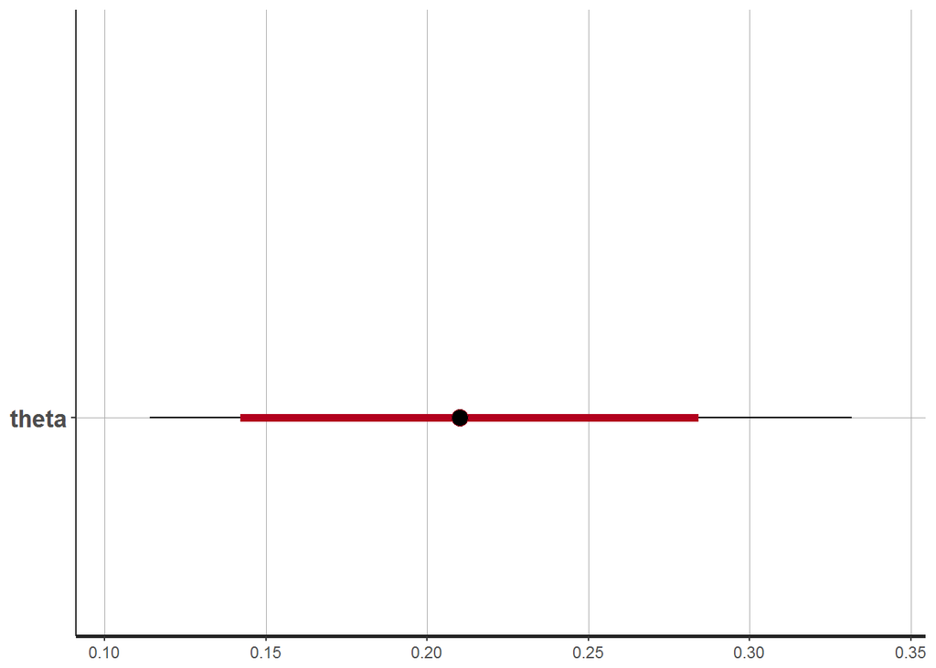

```r
#saveGraph(file=paste0(fileNameRoot,"StanTrace"),type="eps")
#openGraph()
plot(stanFit,pars=c("theta"))
```

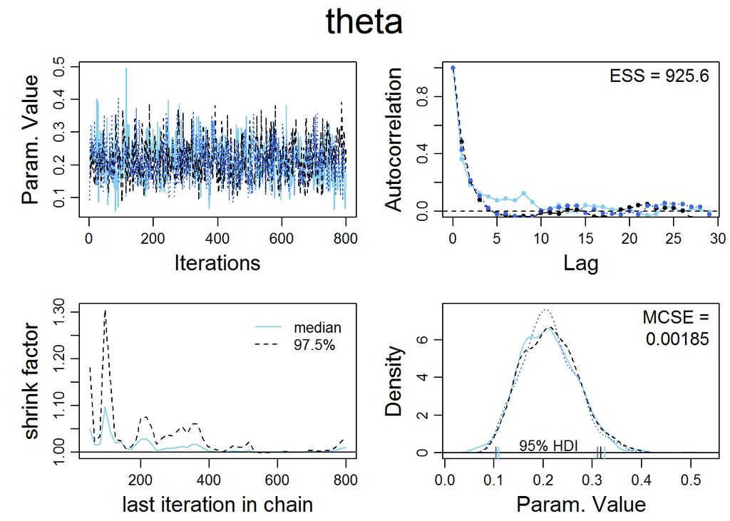

```r
#saveGraph(file=paste0(fileNameRoot,"StanPlot"),type="eps")

# Make graphs:
# For consistency with JAGS-oriented functions in DBDA2E collection,
# convert stan format to coda format. This excludes warmup and thinned steps.
mcmcCoda = mcmc.list( lapply( 1:ncol(stanFit) ,
                              function(x) { mcmc(as.array(stanFit)[,x,]) } ) )
diagMCMC( mcmcCoda , parName=c("theta") )
#saveGraph(file=paste0(fileNameRoot,"Diag"),type="eps")
```

## 3.2 Repeated use of the same DSO

Make another data set.

```r
# Specify data:
N = 50 ; z = 40
y = c(rep(1,z),rep(0,N-z))
dataList = list(
  y = y ,
  N = N
)
dataList
```

```
## $y
##  [1] 1 1 1 1 1 1 1 1 1 1 1 1 1 1 1 1 1 1 1 1 1 1 1 1 1 1 1 1 1 1 1 1 1 1 1
## [36] 1 1 1 1 1 0 0 0 0 0 0 0 0 0 0
##
## $N
## [1] 50
```

Run MCMC with these data.  
Note that we use the same dynamic shared object (DSO)

```r
# Generate posterior sample:
stanFit <- sampling( object=stanDso ,
                     data = dataList ,
                     chains = 3 ,
                     iter = 1000 ,
                     warmup = 200 ,
                     thin = 1 )
```

[output not shown]

[output cut: 16 more lines]

```
## Iteration: 100 / 1000 [ 10%]  (Warmup)
## Iteration: 200 / 1000 [ 20%]  (Warmup)
## Iteration: 201 / 1000 [ 20%]  (Sampling)
## Iteration: 300 / 1000 [ 30%]  (Sampling)
## Iteration: 400 / 1000 [ 40%]  (Sampling)
## Iteration: 500 / 1000 [ 50%]  (Sampling)
## Iteration: 600 / 1000 [ 60%]  (Sampling)
## Iteration: 700 / 1000 [ 70%]  (Sampling)
## Iteration: 800 / 1000 [ 80%]  (Sampling)
## Iteration: 900 / 1000 [ 90%]  (Sampling)
## Iteration: 1000 / 1000 [100%]  (Sampling)
##
##  Elapsed Time: 0.003 seconds (Warm-up)
##                0.01 seconds (Sampling)
##                0.013 seconds (Total)
```

Use `shinystan`.

```r
launch_shinystan(stanFit)
```

Or:

```r
mySecondStanFit<-as.shinystan(stanFit)
save(mySecondStanFit,file=paste(datapath,"secondstanfit.Rdata",sep="/"))
```

```r
#Not evaluated in Rmd
launch_shinystan(mySecondStanFit)
```

```r
#Not evaluated in Rmd
load(paste(datapath,"secondstanfit.Rdata",sep="/"))
launch_shinystan(mySecondStanFit)
```

Explore the graphs.

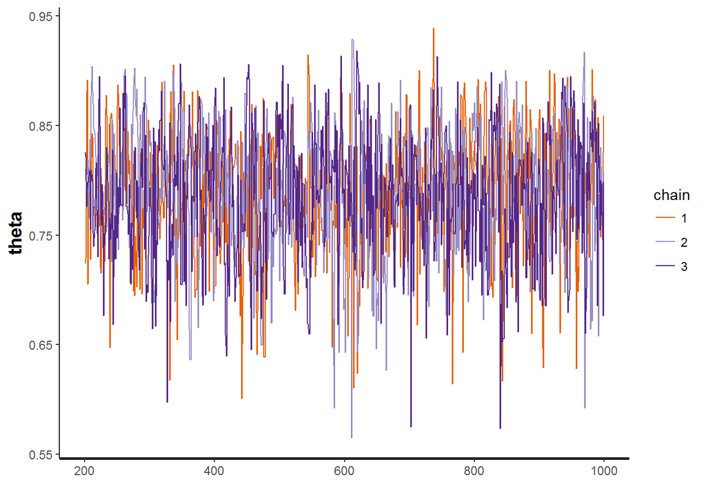

```r
#openGraph()
traceplot(stanFit,pars=c("theta"))
```

```
## ci_level: 0.8 (80% intervals)
```

```
## outer_level: 0.95 (95% intervals)
```

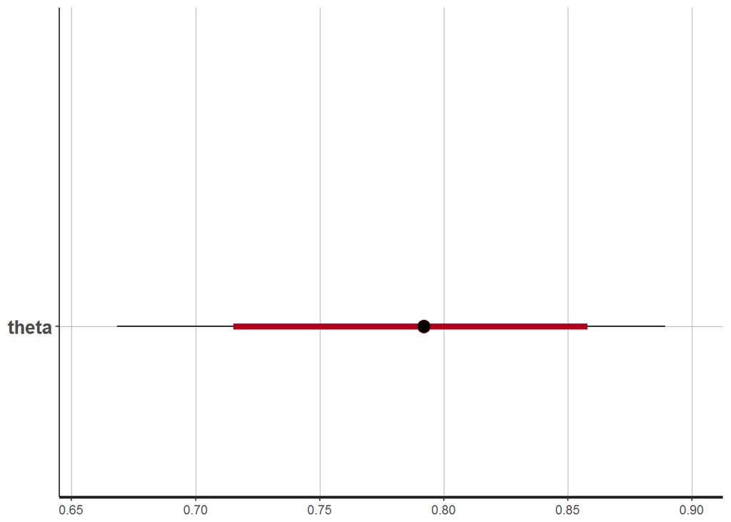

```r
#openGraph()
plot(stanFit,pars=c("theta"))
```

```r
# Make graphs:
# For consistency with JAGS-oriented functions in DBDA2E collection,
# convert stan format to coda format. This excludes warmup and thinned steps.
mcmcCoda = mcmc.list( lapply( 1:ncol(stanFit) ,
                              function(x) { mcmc(as.array(stanFit)[,x,]) } ) )
diagMCMC( mcmcCoda , parName=c("theta") )
```

[output not shown]

## 3.3 General structure of model description in Stan

```r
data {
  ...declarations...
}
transformed data {
  ...declarations...statements...
}
parameters {
  ...declarations...
}
transformed parameters {
  ...declarations...statements...
}
model {
  ...declarations...statements...
}
generated quantities {
  ...declarations...statements...
}
```

The lines of description are processed in order.

## 3.4 The following example shows how to sample from prior distribution

It may be useful to sample from prior distributions.

- For checking if the prior actually has the properties we wanted it to have when translated our prior knowledge in terms of prior distribution.
- For checking the shape of prior distribution in middle levels of hierarchical model when explicit prior was specified on the top level.
- For checking implied shape of the prior, for example, prior for difference of results for control and treated groups when we specify only separate priors for each group.

In Stan sampling from prior is done by commenting out description of likelihood function, but still leaving description of data in specifications of the model.

Use the code from the previous section to sample from prior distribution.

```r
#------------------------------------------------------------------------------
# Generate sample from prior:

# Specify model:
modelString = "
  data {
    int<lower=0> N ;
    int y[N] ;
  }
  parameters {
    real<lower=0,upper=1> theta ;
  }
  model {
    theta ~ beta(1,1) ;
//    y ~ bernoulli(theta) ;  // likelihood commmented out
  }
" # close quote for modelString

# Translate model to C++ and compile to DSO:
stanDso <- stan_model( model_code=modelString )
```

[output not shown]

```r
# Specify data:
N = 50 ; z = 10
y = c(rep(1,z),rep(0,N-z))
dataList = list(
  y = y ,
  N = N
)

# Generate posterior sample:
stanFit <- sampling( object=stanDso ,
                     data = dataList ,
                     chains = 3 ,
                     iter = 1000 ,
                     warmup = 200 ,
                     thin = 1 )
```

[output not shown]

[output cut: 16 more lines]

```
## Iteration: 100 / 1000 [ 10%]  (Warmup)
## Iteration: 200 / 1000 [ 20%]  (Warmup)
## Iteration: 201 / 1000 [ 20%]  (Sampling)
## Iteration: 300 / 1000 [ 30%]  (Sampling)
## Iteration: 400 / 1000 [ 40%]  (Sampling)
## Iteration: 500 / 1000 [ 50%]  (Sampling)
## Iteration: 600 / 1000 [ 60%]  (Sampling)
## Iteration: 700 / 1000 [ 70%]  (Sampling)
## Iteration: 800 / 1000 [ 80%]  (Sampling)
## Iteration: 900 / 1000 [ 90%]  (Sampling)
## Iteration: 1000 / 1000 [100%]  (Sampling)
##
##  Elapsed Time: 0.002 seconds (Warm-up)
##                0.013 seconds (Sampling)
##                0.015 seconds (Total)
```

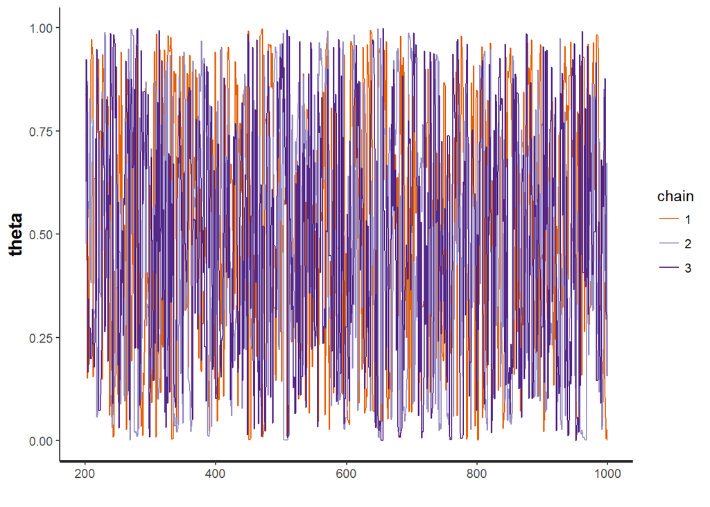

```r
#openGraph()
traceplot(stanFit,pars=c("theta"))
```

```
## ci_level: 0.8 (80% intervals)
```

```
## outer_level: 0.95 (95% intervals)
```

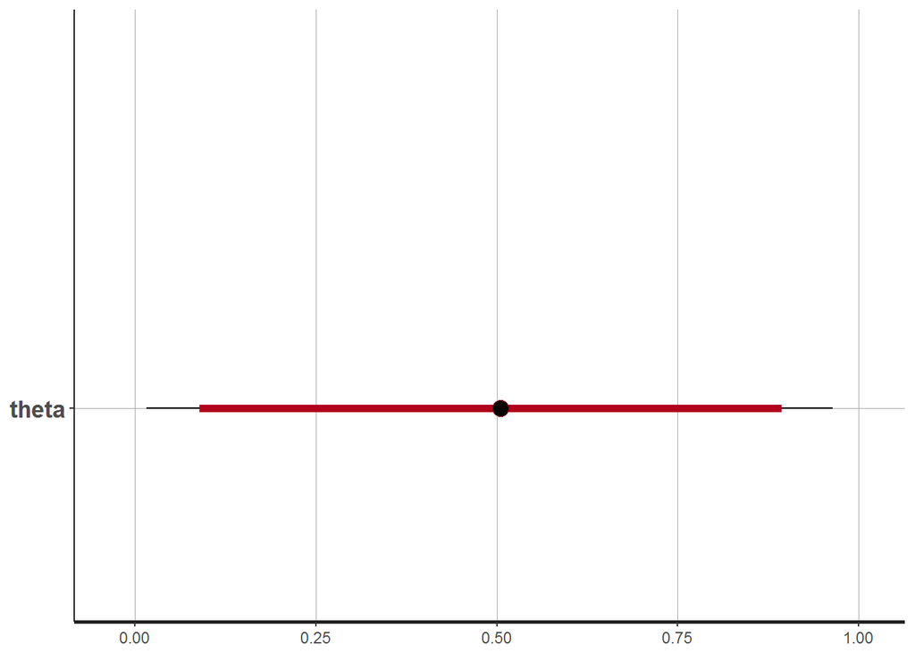

```r
#openGraph()
plot(stanFit,pars=c("theta"))
```

```r
# Make graphs:
# For consistency with JAGS-oriented functions in DBDA2E collection,
# convert stan format to coda format. This excludes warmup and thinned steps.
mcmcCoda = mcmc.list( lapply( 1:ncol(stanFit) ,
                              function(x) { mcmc(as.array(stanFit)[,x,]) } ) )
diagMCMC( mcmcCoda , parName=c("theta") )
```

[output not shown]

# 4 Therapeutic touch example [K], page 240

## 4.1 The problem

“Therapeutic touch is a nursing technique in which the practitioner manually manipulates the “energy field” of a patient who is suffering from a disease. The practitioner holds her or his hands near but not actually touching the patient, and repatterns the energy field to relieve congestion and restore balance, allowing the body to heal. Rosa, Rosa, Sarner, and Barrett (1998) reported that therapeutic touch has been widely taught and widely used in nursing colleges and hospitals despite there being little if any evidence of its efficacy.  
Rosa et al. (1998) investigated a key claim of practitioners of therapeutic touch, namely, that the practitioners can sense a body’s energy field. If this is true, then practitioners should be able to sense which of their hands is near another person’s hand, even without being able to see their hands. The practitioner sat with her hands extended through cutouts in a cardboard screen, which prevented the practitioner from seeing the experimenter. On each trial, the experimenter flipped a coin and held her hand a few centimeters above one or the other of the practitioner’s hands, as dictated by the flip of the coin. The practitioner then responded with her best guess regarding which of her hand’s was being hovered over.  
Each trial was scored as correct or wrong. The experimenter (and co-author of the article) was 9-years old at the time.  
Each practitioner was tested for 10 trials. There were a total of 21 practitioners in the study, seven of whom were tested twice approximately a year apart. The retests were counted by the authors as separate subjects, yielding 28 nominal subjects.”  
The proportions correct for the 28 subjects are shown in Figure 9.9. of the book.  
Chance performance (guessing) is 0.50.  
The question is how much the group as a whole differed from chance performance, and how much any individuals differed from chance performance?  
This hierarchical model is appropriate for these data, because it estimates the underlying ability of each subject while simultaneously estimating the modal ability of the group and the consistency of the group.  
Moreover, the distribution of proportions correct across subjects can be meaningfully described as a beta distribution.  
With 28 subjects, there are a total of 30 parameters being estimated.

The example runs with the script “Stan-Ydich-XnomSsubj-MbernBetaOmegaKappa.R” given in the book.

```r
source(paste(datapath,"Stan-Ydich-XnomSsubj-MbernBetaOmegaKappa.R",sep="/"))
show(genMCMC)
```

## 4.2 Solution in Stan

Here we call Stan directly.

Read the data.  
Create the data list for the model.

```r
myData = read.csv(paste(datapath,"TherapeuticTouchData.csv",sep="/"))

y = as.numeric(myData$y)
s = as.numeric(myData$s) # ensures consecutive integer levels
# Do some checking that data make sense:
if ( any( y!=0 & y!=1 ) ) { stop("All y values must be 0 or 1.") }
Ntotal = length(y)
Nsubj = length(unique(s))
  # Specify the data in a list, for later shipment to JAGS:
dataList = list(
  y = y ,
  s = s ,
  Ntotal = Ntotal ,
  Nsubj = Nsubj
  )
```

Describe the model.

```r
# THE MODEL.
modelString = "
data {
  int<lower=1> Nsubj ;
  int<lower=1> Ntotal ;
  int<lower=0,upper=1> y[Ntotal] ;
  int<lower=1> s[Ntotal] ; // notice Ntotal not Nsubj
}
parameters {
  real<lower=0,upper=1> theta[Nsubj] ; // individual prob correct
  real<lower=0,upper=1> omega ;        // group mode
  real<lower=0> kappaMinusTwo ;        // group concentration minus two
}
transformed parameters {
real<lower=0> kappa ;
  kappa = kappaMinusTwo + 2 ;
}
model {
  omega ~ beta( 1 , 1 ) ;
  kappaMinusTwo ~ gamma( 0.01 , 0.01 ) ; // mean=1 , sd=10 (generic vague)
  // kappaMinusTwo ~ gamma( 1.105125 , 0.1051249 ) ;  # mode=1 , sd=10
  theta ~ beta( omega*(kappa-2)+1 , (1-omega)*(kappa-2)+1 ) ; // vectorized
  for ( i in 1:Ntotal ) {
    y[i] ~ bernoulli( theta[s[i]] ) ;
  }
}
" # close quote for modelString
```

Initialize the model.

```r
  # INTIALIZE THE CHAINS.
  # Initial values of MCMC chains based on data:
  initsList = function() {
    thetaInit = rep(0,Nsubj)
    for ( sIdx in 1:Nsubj ) { # for each subject
      includeRows = ( s == sIdx ) # identify rows of this subject
      yThisSubj = y[includeRows]  # extract data of this subject
      resampledY = sample( yThisSubj , replace=TRUE ) # resample
      thetaInit[sIdx] = sum(resampledY)/length(resampledY)
    }
    thetaInit = 0.001+0.998*thetaInit # keep away from 0,1
    meanThetaInit = mean( thetaInit )
    kappaInit = 100 # lazy, start high and let burn-in find better value
    return( list( theta=thetaInit , omega=meanThetaInit ,
                  kappaMinusTwo=kappaInit-2 ) )
  }
```

Run the chains.

```r
# RUN THE CHAINS
parameters = c( "theta","omega","kappa") # The parameters to be monitored
burnInSteps = 500            # Number of steps to burn-in the chains
nChains = 4                  # nChains should be 2 or more for diagnostics
numSavedSteps=50000
thinSteps=1

# Translate to C++ and compile to DSO:
stanDso <- stan_model( model_code=modelString )
```

[output not shown]

```r
# Get MC sample of posterior:
startTime = proc.time()
stanFit <- sampling( object=stanDso ,
                       data = dataList ,
                       #pars = parameters , # optional
                       chains = nChains ,
                       iter = ( ceiling(numSavedSteps/nChains)*thinSteps
                                +burnInSteps ) ,
                       warmup = burnInSteps ,
                       thin = thinSteps ,
                       init = initsList ) # optional
```

[output not shown]

[output cut: 40 more lines]

[output not shown]

```r
stopTime = proc.time()
duration = stopTime - startTime
show(duration)
```

```
##    user  system elapsed
##   28.64    0.03   28.69
```

## 4.3 Analyze convergence

```r
show(stanFit)
```

```
## Inference for Stan model: 0abcd1c6e22c697f2c611d2f31f359c0.
## 4 chains, each with iter=13000; warmup=500; thin=1;
## post-warmup draws per chain=12500, total post-warmup draws=50000.
##
##                  mean se_mean    sd    2.5%     25%     50%     75%
## theta[1]         0.35    0.00  0.09    0.14    0.30    0.36    0.42
## theta[2]         0.38    0.00  0.09    0.19    0.33    0.39    0.44
## theta[3]         0.41    0.00  0.08    0.23    0.35    0.41    0.46
## theta[4]         0.41    0.00  0.08    0.23    0.35    0.41    0.46
## theta[5]         0.41    0.00  0.08    0.23    0.35    0.41    0.46
## theta[6]         0.41    0.00  0.08    0.23    0.36    0.41    0.46
## theta[7]         0.41    0.00  0.08    0.23    0.35    0.41    0.46
## theta[8]         0.41    0.00  0.08    0.23    0.35    0.41    0.46
## theta[9]         0.41    0.00  0.08    0.23    0.35    0.41    0.46
## theta[10]        0.40    0.00  0.08    0.23    0.35    0.41    0.46
## theta[11]        0.43    0.00  0.08    0.27    0.38    0.43    0.48
## theta[12]        0.43    0.00  0.08    0.27    0.38    0.43    0.48
## theta[13]        0.43    0.00  0.08    0.27    0.38    0.43    0.48
## theta[14]        0.43    0.00  0.08    0.26    0.38    0.43    0.48
## theta[15]        0.43    0.00  0.08    0.27    0.38    0.43    0.48
## theta[16]        0.46    0.00  0.08    0.30    0.40    0.45    0.51
## theta[17]        0.46    0.00  0.08    0.30    0.40    0.45    0.51
## theta[18]        0.46    0.00  0.08    0.30    0.40    0.45    0.51
## theta[19]        0.46    0.00  0.08    0.30    0.40    0.45    0.51
## theta[20]        0.46    0.00  0.08    0.30    0.40    0.45    0.51
## theta[21]        0.46    0.00  0.08    0.30    0.40    0.45    0.51
## theta[22]        0.46    0.00  0.08    0.30    0.40    0.45    0.51
## theta[23]        0.48    0.00  0.09    0.33    0.42    0.47    0.53
## theta[24]        0.48    0.00  0.09    0.33    0.42    0.47    0.53
## theta[25]        0.51    0.00  0.09    0.35    0.44    0.50    0.56
## theta[26]        0.51    0.00  0.09    0.35    0.44    0.50    0.56
## theta[27]        0.51    0.00  0.09    0.35    0.44    0.50    0.56
## theta[28]        0.53    0.01  0.10    0.37    0.46    0.52    0.59
## omega            0.44    0.00  0.06    0.35    0.41    0.44    0.46
## kappaMinusTwo   50.50    1.10 53.50    0.00   17.74   33.27   63.16
## kappa           52.50    1.10 53.50    2.00   19.74   35.27   65.16
## lp__          -200.71    1.00 11.61 -229.89 -207.61 -200.61 -193.17
##                 97.5% n_eff Rhat
## theta[1]         0.51   385 1.01
## theta[2]         0.54   751 1.01
```

[output cut: 20 more lines]

```
## theta[23]        0.67 50000 1.00
## theta[24]        0.67 50000 1.00
## theta[25]        0.72   561 1.01
## theta[26]        0.72   569 1.01
## theta[27]        0.72   592 1.01
## theta[28]        0.77   366 1.01
## omega            0.52  2175 1.00
## kappaMinusTwo  199.61  2365 1.00
## kappa          201.61  2365 1.00
## lp__          -179.05   136 1.02
##
## Samples were drawn using NUTS(diag_e) at Wed Apr 25 14:07:25 2018.
## For each parameter, n_eff is a crude measure of effective sample size,
## and Rhat is the potential scale reduction factor on split chains (at
## convergence, Rhat=1).
```

## 4.4 Analyze the results.

```r
launch_shinystan(stanFit)
```

```r
load(paste(datapath,"TouchAnalysisShiny.Rdata",sep="/"))
launch_shinystan(TouchAnalysis)
launch_shinystan(stanFit)
```

```r
names(stanFit)
```

```
##  [1] "theta[1]"      "theta[2]"      "theta[3]"      "theta[4]"
##  [5] "theta[5]"      "theta[6]"      "theta[7]"      "theta[8]"
##  [9] "theta[9]"      "theta[10]"     "theta[11]"     "theta[12]"
## [13] "theta[13]"     "theta[14]"     "theta[15]"     "theta[16]"
## [17] "theta[17]"     "theta[18]"     "theta[19]"     "theta[20]"
## [21] "theta[21]"     "theta[22]"     "theta[23]"     "theta[24]"
## [25] "theta[25]"     "theta[26]"     "theta[27]"     "theta[28]"
## [29] "omega"         "kappaMinusTwo" "kappa"         "lp__"
```

```r
summary(stanFit)
```

```
## $summary
##                       mean      se_mean          sd          2.5%
## theta[1]         0.3547801 0.0047729675  0.09361999  1.430968e-01
## theta[2]         0.3800636 0.0031980410  0.08765080  1.878294e-01
## theta[3]         0.4055493 0.0003693459  0.08258826  2.304938e-01
## theta[4]         0.4050024 0.0003707690  0.08290647  2.292606e-01
## theta[5]         0.4053476 0.0003711992  0.08300267  2.286984e-01
## theta[6]         0.4053769 0.0003727275  0.08334440  2.256939e-01
## theta[7]         0.4052244 0.0003695449  0.08263276  2.291042e-01
## theta[8]         0.4052139 0.0003736686  0.08355484  2.268525e-01
## theta[9]         0.4054652 0.0003706148  0.08287199  2.307659e-01
## theta[10]        0.4049000 0.0003746620  0.08377698  2.282165e-01
## theta[11]        0.4303482 0.0003617192  0.08088287  2.664500e-01
## theta[12]        0.4297482 0.0003619294  0.08092987  2.658733e-01
## theta[13]        0.4300790 0.0003621625  0.08098200  2.661806e-01
## theta[14]        0.4301923 0.0003654126  0.08170874  2.648582e-01
## theta[15]        0.4308127 0.0003664685  0.08194484  2.652302e-01
## theta[16]        0.4559547 0.0003686707  0.08243727  2.986615e-01
## theta[17]        0.4557643 0.0003686235  0.08242672  2.990180e-01
## theta[18]        0.4559771 0.0003694323  0.08260757  2.993047e-01
## theta[19]        0.4562417 0.0003677482  0.08223100  3.006275e-01
## theta[20]        0.4559623 0.0003697553  0.08267981  2.990969e-01
## theta[21]        0.4559184 0.0003737722  0.08357801  2.976350e-01
## theta[22]        0.4557322 0.0003693441  0.08258786  2.974525e-01
## theta[23]        0.4813811 0.0003851515  0.08612250  3.271087e-01
## theta[24]        0.4813086 0.0003848343  0.08605157  3.281901e-01
## theta[25]        0.5062598 0.0039151131  0.09274033  3.500713e-01
## theta[26]        0.5066184 0.0038828006  0.09262855  3.503079e-01
## theta[27]        0.5064652 0.0038088346  0.09266210  3.502692e-01
## theta[28]        0.5318036 0.0052433325  0.10027741  3.715553e-01
## omega            0.4373872 0.0012595363  0.05874639  3.549024e-01
## kappaMinusTwo   50.4953721 1.1001764450 53.49816171  1.483158e-04
## kappa           52.4953721 1.1001764450 53.49816171  2.000148e+00
## lp__          -200.7075555 0.9950495133 11.60529947 -2.298948e+02
##                        25%          50%          75%        97.5%
## theta[1]         0.2988671    0.3647725    0.4198552    0.5136585
## theta[2]         0.3273885    0.3867622    0.4393224    0.5363489
## theta[3]         0.3549520    0.4092630    0.4595267    0.5614923
## theta[4]         0.3538694    0.4088423    0.4597414    0.5619644
## theta[5]         0.3542380    0.4094297    0.4600413    0.5618054
```

[output cut: 330 more lines]

```
##   theta[18]        0.4537993    0.5101808    0.6539225
##   theta[19]        0.4546922    0.5105021    0.6604049
##   theta[20]        0.4527363    0.5096160    0.6569968
##   theta[21]        0.4533458    0.5112070    0.6560205
##   theta[22]        0.4534900    0.5106115    0.6551571
##   theta[23]        0.4785161    0.5423035    0.7159384
##   theta[24]        0.4770470    0.5418153    0.7164513
##   theta[25]        0.5022693    0.5759178    0.7781215
##   theta[26]        0.5025196    0.5739484    0.7818533
##   theta[27]        0.5038998    0.5733928    0.7815384
##   theta[28]        0.5272866    0.6084988    0.8567242
##   omega            0.4358211    0.4639303    0.7420459
##   kappaMinusTwo   30.0819972   59.9274713  191.3196265
##   kappa           32.0819972   61.9274713  193.3196265
##   lp__          -201.7879395 -193.6848599 -179.3773991
```

```
## 'pars' not specified. Showing first 10 parameters by default.
```

```
## ci_level: 0.8 (80% intervals)
```

```
## outer_level: 0.95 (95% intervals)
```

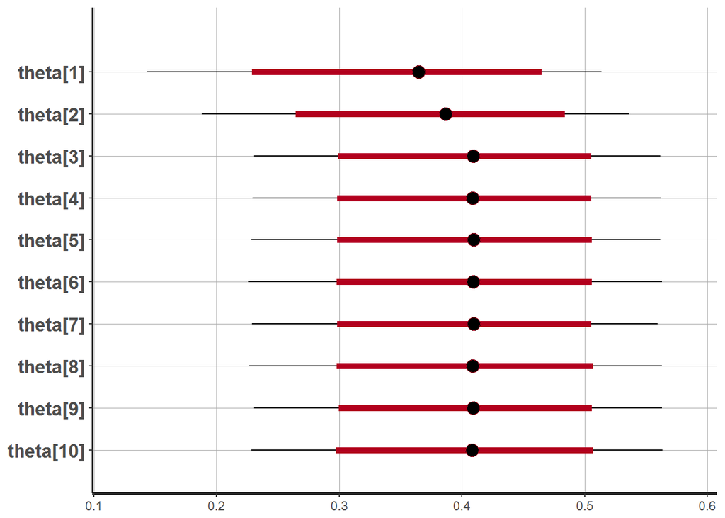

```r
plot(stanFit)
```

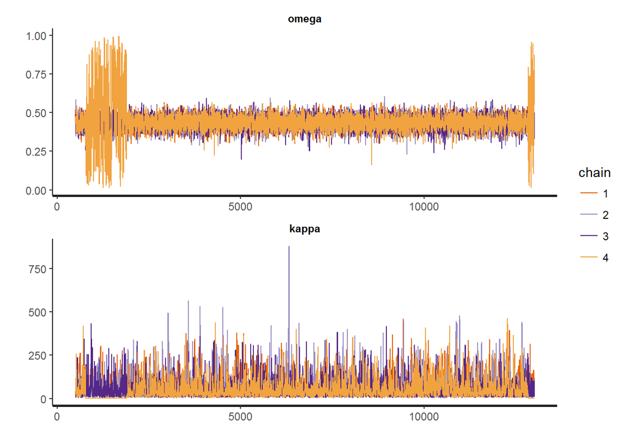

```r
rstan::traceplot(stanFit,pars=c("omega","kappa"), ncol=1, inc_warmup=F)
```

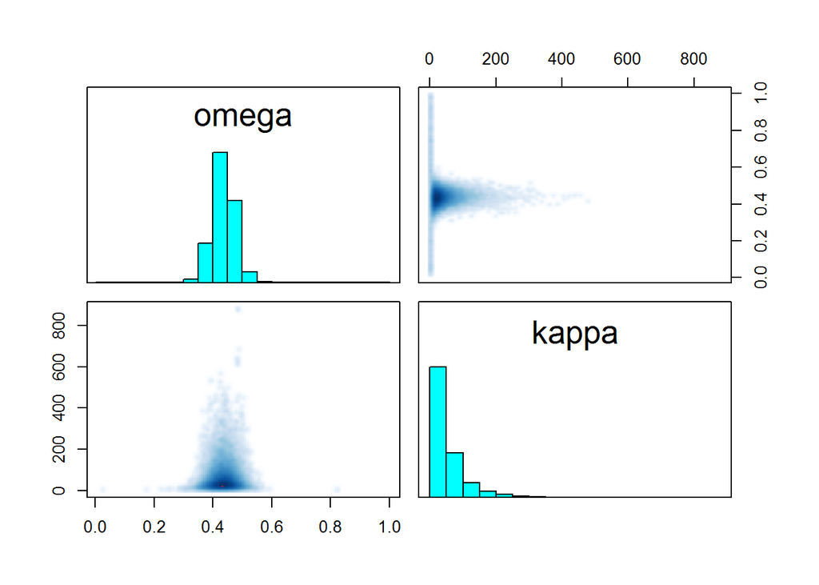

```r
pairs(stanFit, pars=c("omega","kappa"))
```

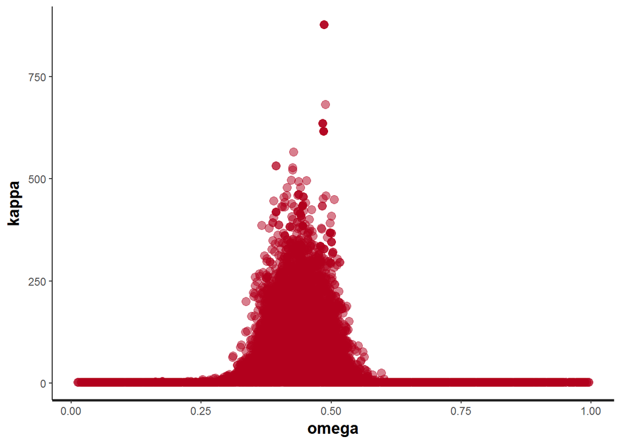

```r
stan_scat(stanFit, pars=c("omega","kappa"))
```

```
## 'pars' not specified. Showing first 10 parameters by default.
```

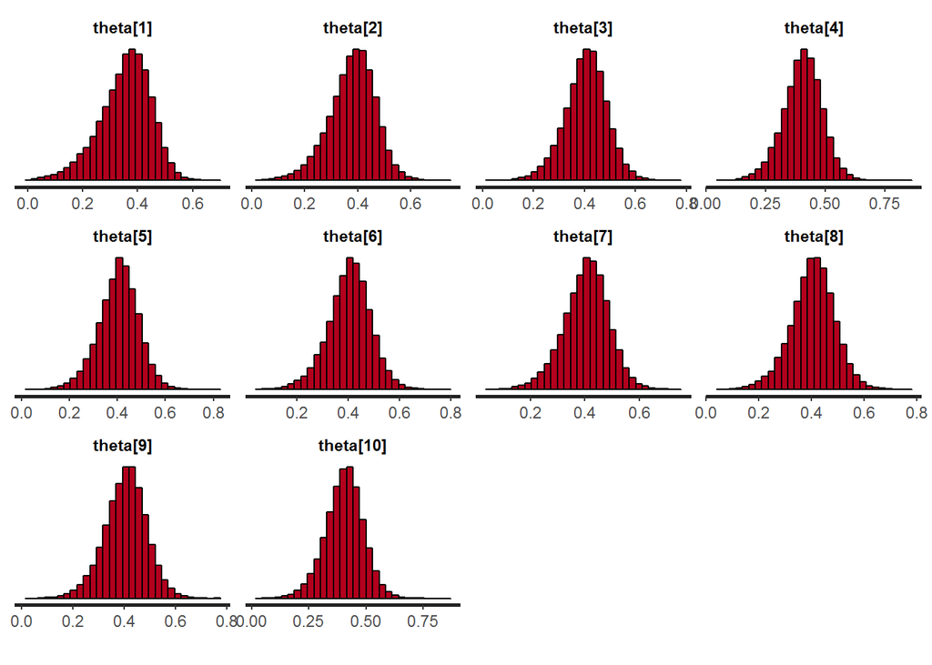

```r
stan_hist(stanFit)
```

```r
stan_dens(stanFit)
```

```
## 'pars' not specified. Showing first 10 parameters by default.
```

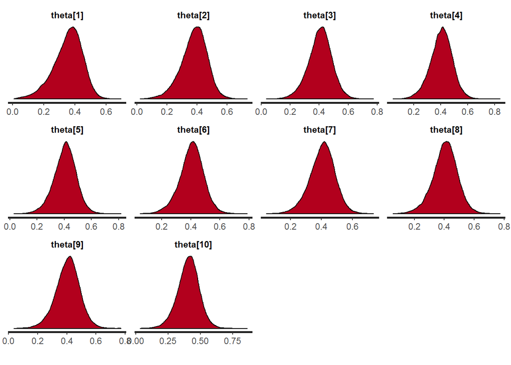

```r
stan_ac(stanFit, separate_chains = T)
```

```
## 'pars' not specified. Showing first 10 parameters by default.
```

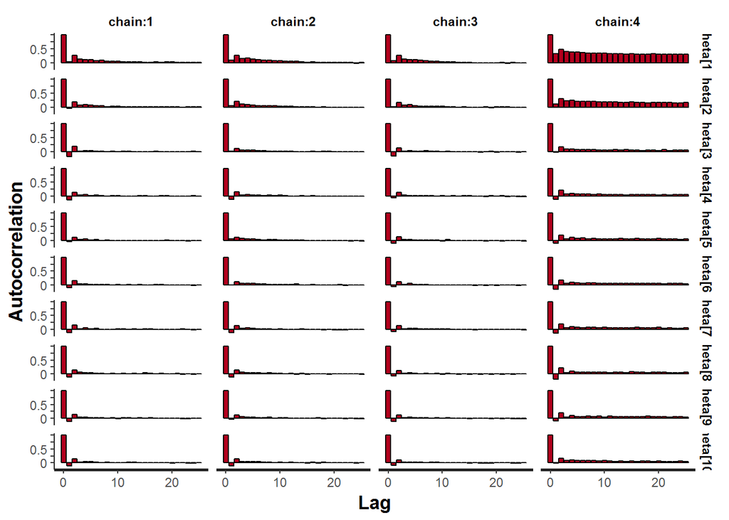

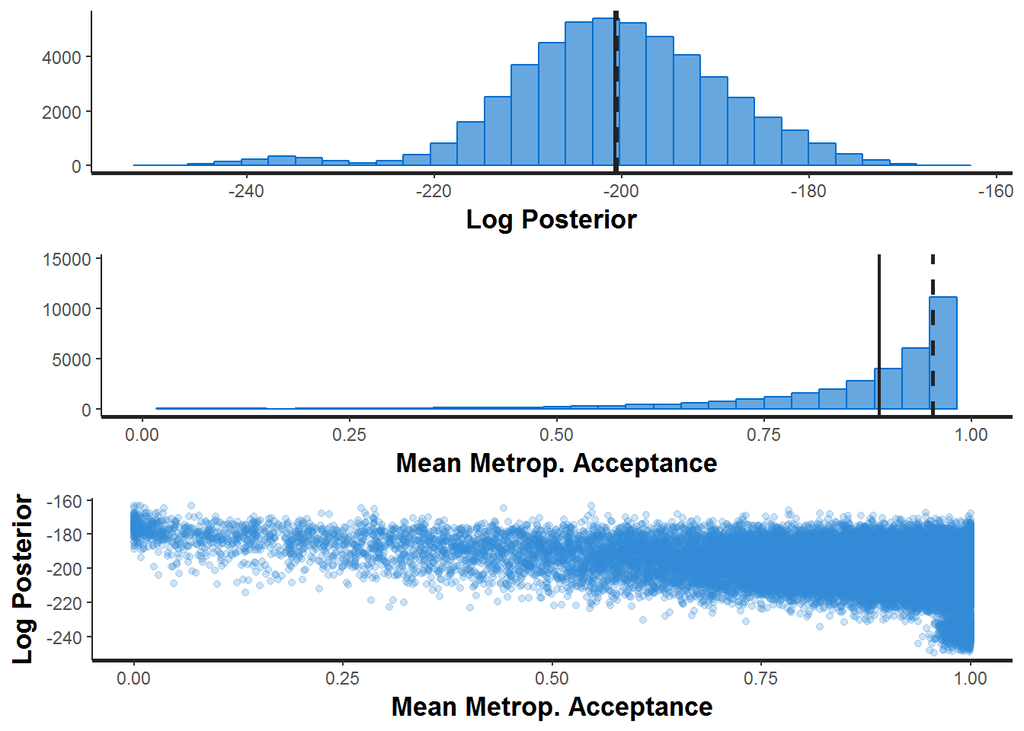

```r
stan_diag(stanFit,information = "sample",chain=0)
```

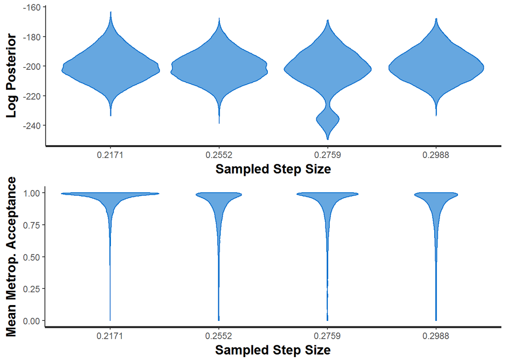

```r
stan_diag(stanFit,information = "stepsize",chain = 0)
```

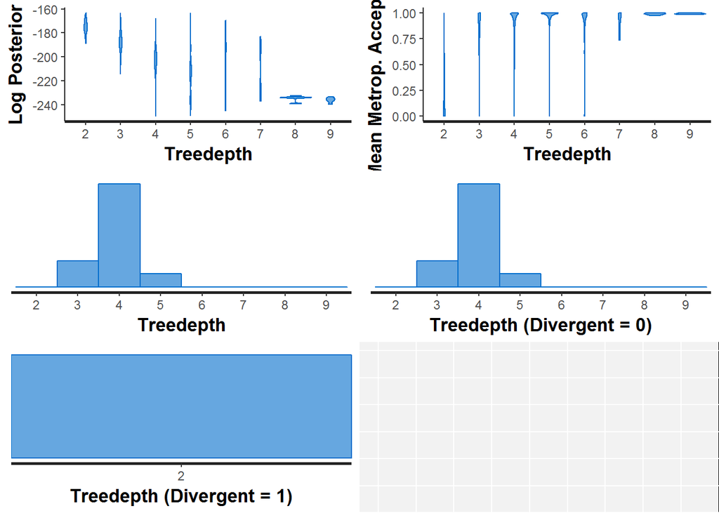

```r
stan_diag(stanFit,information = "treedepth",chain = 0)
```

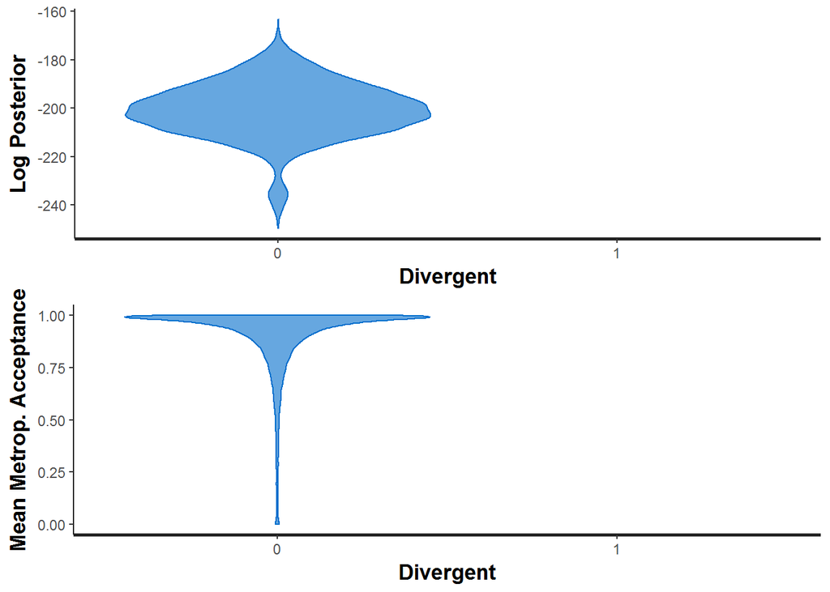

```r
stan_diag(stanFit,information = "divergence",chain = 0)
```

Extract MCMC trajectories of hyperparameters $\omega, \kappa$. Does the pair of hyperparameters $\omega, \kappa$ show any dependence?

```r
OmegaKappa<-cbind(Omega=rstan::extract(stanFit,pars=c("omega","kappa"))$'omega',
                  Kappa=rstan::extract(stanFit,pars=c("omega","kappa"))$'kappa')

head(OmegaKappa)
```

```
##          Omega     Kappa
## [1,] 0.4250432  95.86768
## [2,] 0.4435934  39.27799
## [3,] 0.4126315  27.47503
## [4,] 0.4532459  21.31585
## [5,] 0.4169970  76.33621
## [6,] 0.4502039 120.24215
```

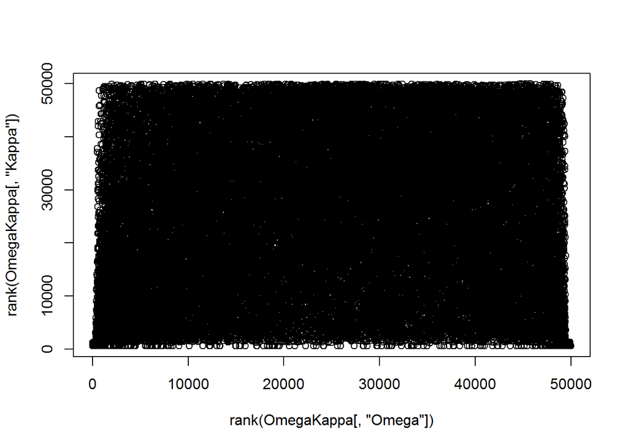

```r
plot(rank(OmegaKappa[,"Omega"]),rank(OmegaKappa[,"Kappa"]))
```

Extract parameters $\theta$ for eache tested individual.

```r
Thetas<-rstan::extract(stanFit,pars=names(stanFit))
Thetas<-matrix(unlist(Thetas), ncol = 32, byrow = F)
colnames(Thetas)<-names(stanFit)
Thetas<-Thetas[,-(29:32)]
head(Thetas)
```

```
##       theta[1]  theta[2]  theta[3]  theta[4]  theta[5]  theta[6]  theta[7]
## [1,] 0.4305854 0.3664646 0.3773410 0.3444345 0.3805902 0.3378871 0.3721128
## [2,] 0.3255224 0.4272542 0.4906504 0.4289340 0.3103238 0.4123272 0.5975468
## [3,] 0.2180233 0.3290103 0.5269708 0.2929682 0.4283900 0.4552347 0.3092087
## [4,] 0.4553761 0.5178791 0.3646321 0.3925299 0.3273242 0.3339863 0.5316617
## [5,] 0.4206381 0.3344264 0.4029091 0.4587875 0.4853567 0.5308787 0.3688734
## [6,] 0.4372336 0.4033223 0.4878137 0.4737927 0.3967518 0.4755407 0.4671190
##       theta[8]  theta[9] theta[10] theta[11] theta[12] theta[13] theta[14]
## [1,] 0.3934685 0.3855831 0.5042760 0.4818063 0.4100607 0.4217589 0.4385536
## [2,] 0.3381859 0.2344856 0.3928229 0.4009248 0.4526734 0.5552585 0.4497698
## [3,] 0.3956007 0.3399134 0.3272812 0.4265597 0.5241429 0.2922473 0.2792944
## [4,] 0.5522191 0.4346431 0.4487691 0.5335108 0.5426185 0.3615109 0.5506746
## [5,] 0.4322950 0.3765202 0.4180903 0.3500866 0.3893152 0.4641001 0.4897874
## [6,] 0.4189075 0.4130062 0.4115343 0.4999867 0.3939998 0.4093385 0.4330946
##      theta[15] theta[16] theta[17] theta[18] theta[19] theta[20] theta[21]
## [1,] 0.3651301 0.4665104 0.4222156 0.4691933 0.3421872 0.2931713 0.4547536
## [2,] 0.4334280 0.3494311 0.5035960 0.3859953 0.4616080 0.3445323 0.4580886
## [3,] 0.4493512 0.4086562 0.5301483 0.3129538 0.4078947 0.3977230 0.4671565
## [4,] 0.3561181 0.4696890 0.6698988 0.3704422 0.5492399 0.5287168 0.5195166
## [5,] 0.4706454 0.3657639 0.4665486 0.4591282 0.5415232 0.5320418 0.3988667
## [6,] 0.4502894 0.5405889 0.4517920 0.3942381 0.5063259 0.4055960 0.4419340
##      theta[22] theta[23] theta[24] theta[25] theta[26] theta[27] theta[28]
## [1,] 0.4779248 0.3958797 0.4539340 0.4932824 0.4322854 0.4078275 0.4489604
## [2,] 0.4681379 0.5075566 0.5335180 0.4195432 0.5348130 0.4860173 0.4390301
## [3,] 0.4219988 0.4975645 0.5236435 0.3782012 0.4364578 0.5291138 0.4588146
## [4,] 0.6100023 0.5587502 0.7296187 0.5468115 0.3859664 0.5141210 0.6661071
## [5,] 0.4166077 0.4546266 0.4760378 0.3716381 0.4609403 0.5142585 0.5258721
## [6,] 0.3913956 0.4269336 0.4724683 0.4999416 0.5061361 0.4387178 0.5675526
```

Going back to the questions of the example.

**How much the group as a whole differed from chance performance?**

```r
(sigmas<-apply(Thetas,2,sd))
```

```
##   theta[1]   theta[2]   theta[3]   theta[4]   theta[5]   theta[6]
## 0.09361999 0.08765080 0.08258826 0.08290647 0.08300267 0.08334440
##   theta[7]   theta[8]   theta[9]  theta[10]  theta[11]  theta[12]
## 0.08263276 0.08355484 0.08287199 0.08377698 0.08088287 0.08092987
##  theta[13]  theta[14]  theta[15]  theta[16]  theta[17]  theta[18]
## 0.08098200 0.08170874 0.08194484 0.08243727 0.08242672 0.08260757
##  theta[19]  theta[20]  theta[21]  theta[22]  theta[23]  theta[24]
## 0.08223100 0.08267981 0.08357801 0.08258786 0.08612250 0.08605157
##  theta[25]  theta[26]  theta[27]  theta[28]
## 0.09274033 0.09262855 0.09266210 0.10027741
```

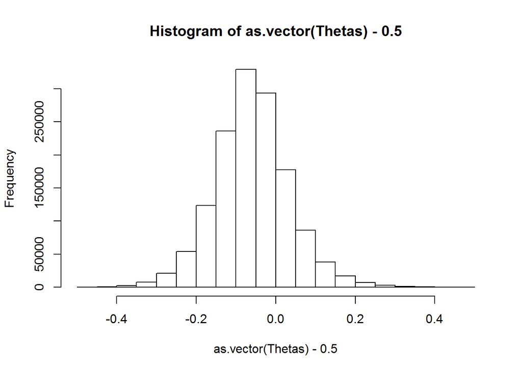

```r
hist(as.vector(Thetas)-.5)
```

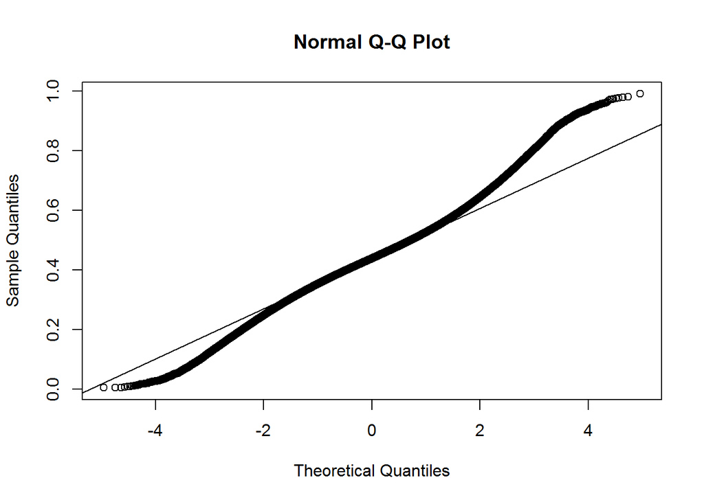

```r
qqnorm(as.vector(Thetas))
qqline(as.vector(Thetas))
```

```r
t.test(as.vector(Thetas),mu=0.5)
```

```
##
##  One Sample t-test
##
## data:  as.vector(Thetas)
## t = -743.76, df = 1400000, p-value < 2.2e-16
## alternative hypothesis: true mean is not equal to 0.5
## 95 percent confidence interval:
##  0.4403250 0.4406387
## sample estimates:
## mean of x
## 0.4404818
```

The number of degrees of freedom is so large that t.test becomes very sensitive.  
The distribution has fat tails because of non-constant standard deviations.

Bayesian approach is based on HDI.

```r
library(HDInterval)
```

```r
hdi(as.vector(Thetas))
```

```
##     lower     upper
## 0.2507363 0.6359776
## attr(,"credMass")
## [1] 0.95
```

What makes HDI so much wider than confidence interval?

**How much any individuals differed from chance performance?**

```r
apply(Thetas,2,function(z) hdi(z))
```

```
##        theta[1]  theta[2]  theta[3]  theta[4]  theta[5]  theta[6]
## lower 0.1626369 0.1958370 0.2346647 0.2356309 0.2334815 0.2366821
## upper 0.5283600 0.5430458 0.5651743 0.5678480 0.5656230 0.5722078
##        theta[7]  theta[8]  theta[9] theta[10] theta[11] theta[12]
## lower 0.2372960 0.2285358 0.2317364 0.2314371 0.2696789 0.2673011
## upper 0.5660644 0.5642241 0.5634794 0.5665684 0.5933131 0.5921146
##       theta[13] theta[14] theta[15] theta[16] theta[17] theta[18]
## lower 0.2638509 0.2642675 0.2695660 0.2920810 0.2930087 0.2938075
## upper 0.5894353 0.5927168 0.5996564 0.6219067 0.6229369 0.6239000
##       theta[19] theta[20] theta[21] theta[22] theta[23] theta[24]
## lower 0.2915253 0.2918348 0.2971918 0.2896776 0.3196355 0.3215379
## upper 0.6183420 0.6232336 0.6315775 0.6219956 0.6611425 0.6627812
##       theta[25] theta[26] theta[27] theta[28]
## lower 0.3331648 0.3341941 0.3390734 0.3577687
## upper 0.6939427 0.6987424 0.7024093 0.7443062
```

HDIs of all chains contain 0.5.

```r
apply(Thetas,2,function(z) t.test(as.vector(z),mu=0.5)$p.value)
```

```
##     theta[1]     theta[2]     theta[3]     theta[4]     theta[5]
## 0.000000e+00 0.000000e+00 0.000000e+00 0.000000e+00 0.000000e+00
##     theta[6]     theta[7]     theta[8]     theta[9]    theta[10]
## 0.000000e+00 0.000000e+00 0.000000e+00 0.000000e+00 0.000000e+00
##    theta[11]    theta[12]    theta[13]    theta[14]    theta[15]
## 0.000000e+00 0.000000e+00 0.000000e+00 0.000000e+00 0.000000e+00
##    theta[16]    theta[17]    theta[18]    theta[19]    theta[20]
## 0.000000e+00 0.000000e+00 0.000000e+00 0.000000e+00 0.000000e+00
##    theta[21]    theta[22]    theta[23]    theta[24]    theta[25]
## 0.000000e+00 0.000000e+00 0.000000e+00 0.000000e+00 2.332108e-51
##    theta[26]    theta[27]    theta[28]
## 2.564719e-57 9.587568e-55 0.000000e+00
```

FNP approach rejects all the null hypotheses.